# RStudio Projects

## Oakland R Beginners

Project for this presentation at https://github.com/ds4ci/rsProject

### What We Will Cover

- Why Projects?
- Directory Structures
- Creating a New Project
- Tying in Git & GitHub
- Preview of upcoming *R Packages* talk
- Wrap-up

## Why Projects?

- Keep all project data together
  - Including command history specific to project
- Let RStudio handle working directory/folder location
  - Then use relative paths
  - For portable projects!
- Use Git/GitHub for backup & version control
  - Not just for R code!
- Stay tuned for creating packages

## Directory Structures

### Simple Case - Just a few projects

- proj
  - My1stProject
    - R
    - [SQL]
    - [DataIn]
    - [DateOut]
    - [Results]
    - [Background]
  - My2ndProject
    - …

[indicates optional folder]

### When You Have Many Clients

- proj
  - Client1
    - [DataIn]
    - [DataOut]
    - C1Proj1
      - R
      - …
    - C1Proj2
      - …
  - Client2
    - …

### When You Have a Major Client

- proj
  - Client1
    - C1FirstMajorProj
      - C1FMP_Subproj1
        - R
        - …
      - C1FMP_Subproj2 (could be a package!)
        - …
    - C1SecondMajorProj
      - …
  - Client2

## Setting-up a New Project

Using this project as the example.

### Creating the Project in RStudio

Once basic directory structure is set up,

RStudio menu: File | New Project…

[figure not shown]

### Add Some Code

Create a new sample R Notebook from R Studio menu: Green + | R Notebook

Save in the R folder as “SampleRNotebook.Rmd”. Preview it. You should see something like:

[figure not shown]

## Tying in Git & GitHub

### Getting Git & GitHub

To install Git see the R Studio article:

https://support.rstudio.com/hc/en-us/articles/200532077

If you need a GitHub account, sign up at https://github.com

If you are new to Git & GitHub, watch Garrett Grolemund's excellent webinar: https://www.rstudio.com/resources/webinars/rstudio-essentials-webinar-series-managing-part-2/

### Initial Git Commit

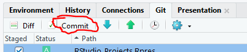

[figure not shown]

### Make a New Repo in Your GitHub

[figure not shown]

### Copy Commands to Execute in Local Shell

[figure not shown]

### Run in Shell to Link & Initialize GitHub Repo

Open shell with RStudio menu Git | Gear | Shell…

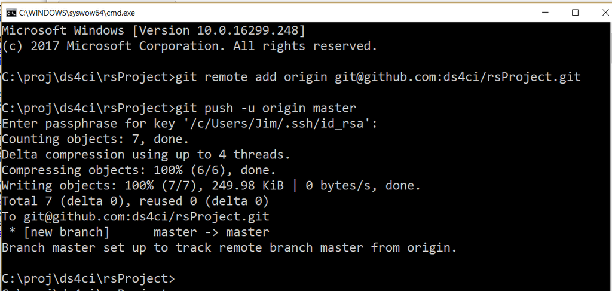

### Resulting GitHub Repo

[figure not shown]

### Write README in R Markdown

```
---
title: "README"
output: github_document
---
## rsProject

Is both an example and a presentation of the basics of
setting up a *project* in RStudio.
. . .
```

Save in the project root as README.Rmd and knit:

[figure not shown]

.

### Remember to Commit to Git/GitHub Often!

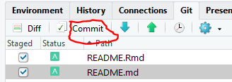

[figure not shown]

[figure not shown]

## Preview - R Packages

An R Package is a specially formatted project.

Coming up:

Writing R packages to simplify the R world for you and your collegues.

Then submit to CRAN for fame & fortune(?).

### Package Development Resources

In the meantime, you can see…

Garrett's webinar: https://www.rstudio.com/resources/webinars/rstudio-essentials-webinar-series-programming-part-3/

The package development cheet sheet: https://github.com/rstudio/cheatsheets/raw/master/package-development.pdf

Hadley's R Packages book: http://r-pkgs.had.co.nz/

## Wrap-up

### What We Covered

- Why projects are cool & useful
- Various directory structures
- Creating a new project
- Using Git & GitHub for backup, version control, & sharing
- Preview look at R packages

The GitHub *RStudio Projects* repo is at https://github.com/ds4ci/rsProject

### Learning More

- Garrett's Projects webinar: https://www.rstudio.com/resources/webinars/rstudio-essentials-webinar-series-managing-change-part-1/ Project discussion starts at ~ 13 minutes.
- Garrett's Git/GitHub webinar: https://www.rstudio.com/resources/webinars/rstudio-essentials-webinar-series-managing-part-2/
- The RStudio IDE Cheat Sheet: https://github.com/rstudio/cheatsheets/raw/master/rstudio-ide.pdf
- Google “R Project Structure” for various ideas on directory structure.
- Making _R Presentations: https://support.rstudio.com/hc/en-us/sections/200130218-R-Presentations
- Jim's archives: https://ds4ci.org/archives/

## Thank You!

Jim@DS4CI.org